# Summary of current Beaver population dynamics models

Jake Ferguson and Sean Johnson-Bice

June 20, 2018

## The model

We modeled the log-densities of beavers $\left( X=\ln(D) \right)$ using a Gompertz model. The standard interpretation of the Gompertz model is that there is an siz-eindependent component of mortality as well as a component of mortality that increases exponentially with population size. For population $i$ in year $j$ with a vector of covariates ($\mathbf{Z}$) measured in year $j$ we modeled

$$\begin{aligned}
X_{i,j} &= a + u_{i} + (1 - b) X_{i,j} + \boldsymbol{\beta} \mathbf{Z}_j + \varepsilon_{i,j} \\
u_{i} &\sim \mathrm{Norm}\left(0,\, \sigma_a \right) \\
\varepsilon_{i,j} &\sim \mathrm{Norm}\left(0,\, \sigma_i \right).
\end{aligned}$$
The intrinsic growth rate is given by $a$ and the random effect $u_i$ allows this term to vary from population to population. The strength of density dependence is given by $b$, when $b=0$ the model is density independent. The effects of extrinsic covariates on population growth are determined by the vector $\boldsymbol{\beta}$ and $\varepsilon_{i,j}$ is the extrinsic variability that is not otherwise accounted for in the model.

The priors we used were (need to double check these)
$$\begin{aligned}
a &\sim \mathrm{Norm}(0,\, 10)\\
\beta &\sim \mathrm{Norm}(0, 10)\\
b &\sim \mathrm{Unif}(-4,\,2)\\
\sigma_a &\sim \mathrm{Unif}(0,\, 20)\\
\sigma_i &\sim \mathrm{Unif}(0,\, 20)
\end{aligned}$$

## Model fits

We fit our models in JAGS with a burnin of $10^4$ draws followed by $10^6$ draws from the posterior. We then thinned these draws by 100 for a total of $10^4$ posterior samples. Some aspects of model fits are described below:

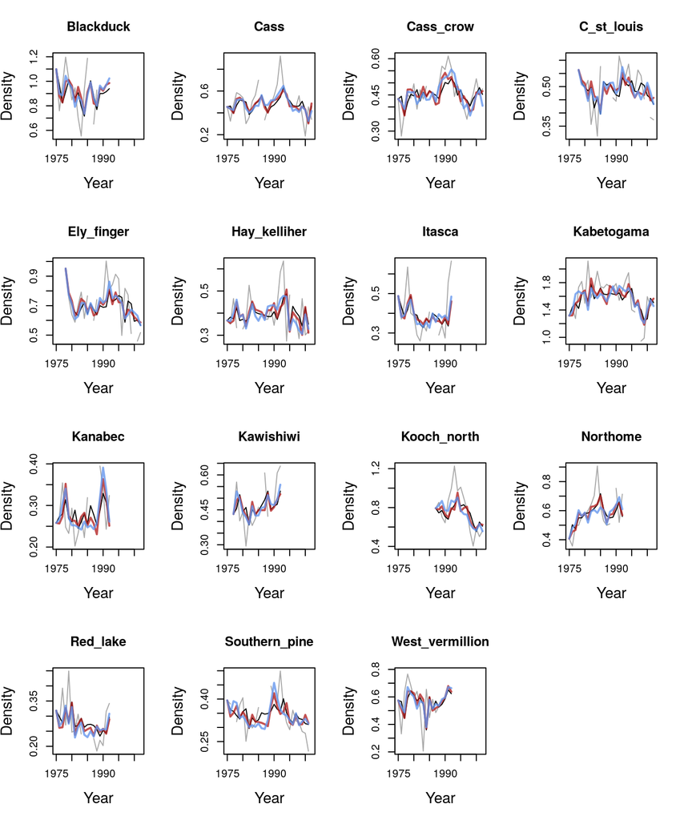

Gray lines are data, black lines are Gompertz model predictions, red lines are predictions of Gompertz with PDSI covariates, blue lines are predictions of Gompertz with PPT covariates.

Below are the posterior estimates of environmental covariates.

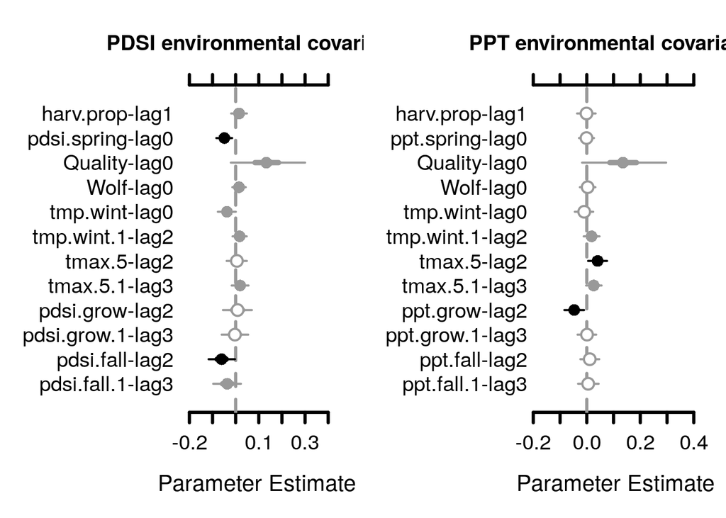

Posterior distributions of the environmental covariates.

The estimate of the average log-intrinsic growth rate across populations, $a$, (reported as mean (standard deviation)) is -0.37 (0.09) and the strength of density dependence, $b$ is 0.56 (0.07). There was a great deal of variation in $a$ from population to population, below we plot these estimates.

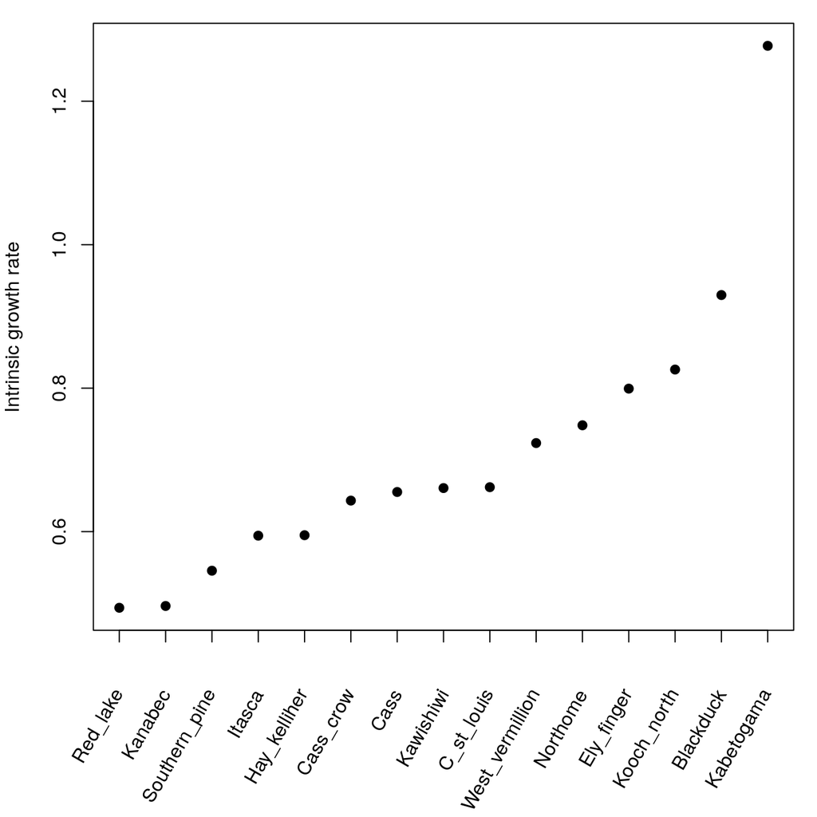

Add uncertainty in this figures. Intrinsic growth rate is exp(a). Estimates from model without any environmental covariates.

There is quite a bit of variability here that we are unable to explain, we should think this over. We fit a model with covariates to and one without covariates. The difference in the DIC values between the models is 12.9 suggesting that including covariates leads to a more parsimonious description of the data.

| Model.name | DIC | R.2 | Average.prediction.error |
| --- | --- | --- | --- |
| Density indpendent | 70.52 | NA | 45.92 |
| Gompertz model | 5.38 | 0.29 | 11.98 |
| Gompertz model + PDSI | -7.55 | 0.38 | 9.96 |
| Gompertz model + PPT | 8.16 | 0.33 | 10.6 |

Now we check the prediction error by holding out the last 30% of the observerations for each population, refitting the models, then try to predict those missing observations. We calculated the average prediction error for each population as $\mathrm{Error}=1/n \sum_t^n \left| D_t - \hat{D}_t \right|$, where $\hat{D}_t$ is the estimate (mean population density) predicted in year $t$. The sum in this equation is over all the datapoints held out of the model fitting, a number that varies from popualtion to population. We will compare the predictions made by a model without covariates to one with covariates. Below are the errors for each populuation.

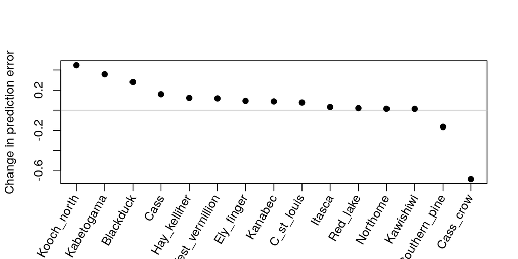

## Full-lag model

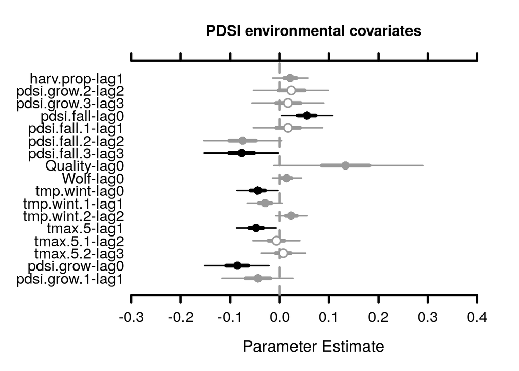

## Site-specific responses to environmental variables

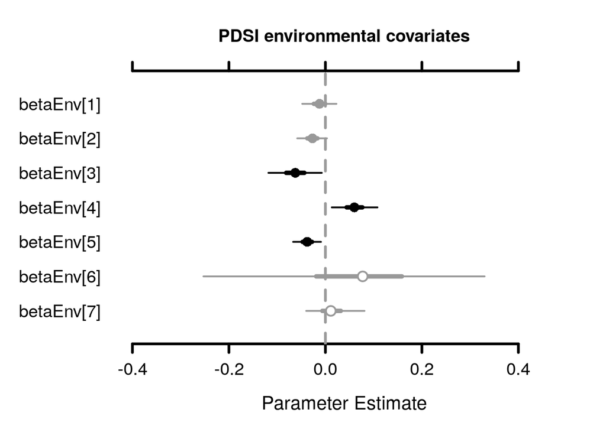

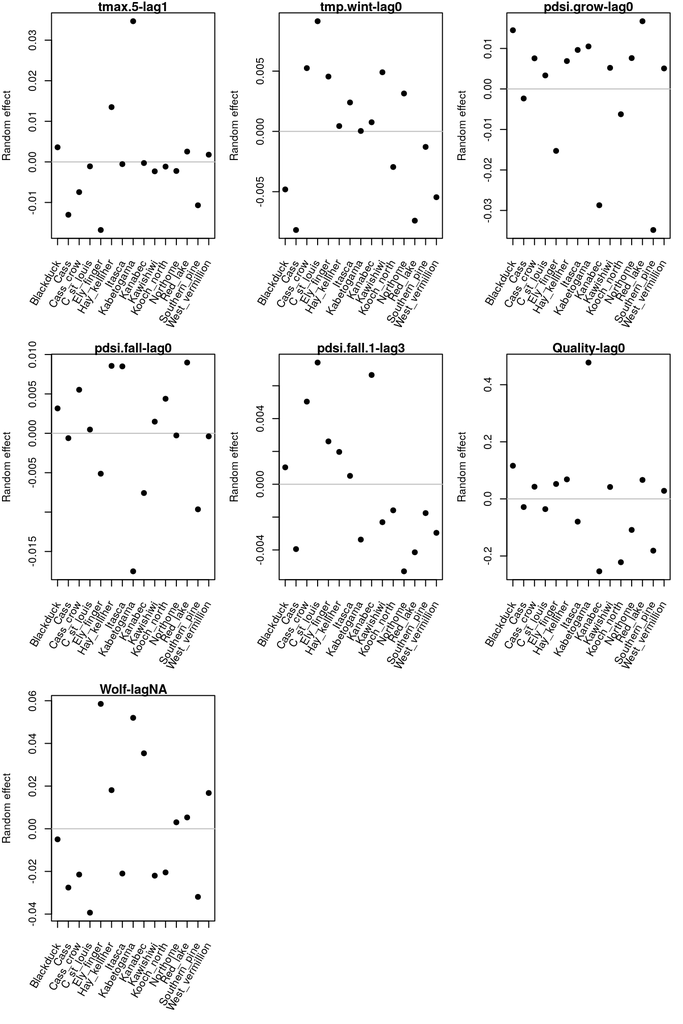

The DIC value (24.31) ($R^2$ = 0.4) (average mean squared error = 12.13) of this model is higher than without the random effects due to the large number of parameters. Probably should just explore this on a subset of the most important predictors from the first analysis. It would be nice to geographic locations to look for trends in winter temperatures. Also note that the random effect of quality doesn’t vary much, except for the effect of Kabetogama.

# LASSO and Ridge regression

[figure not shown]

The total square error of Ridge regression 11.14.

The total square error of LASSO is 10.81.